# COM 6042: Project.

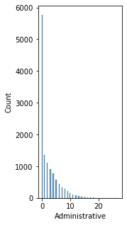

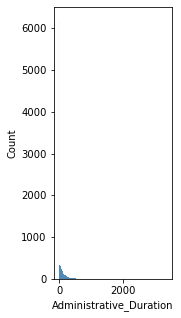

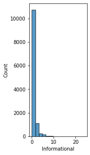

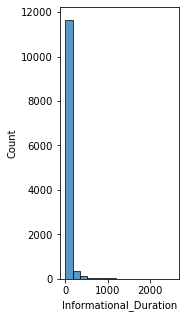

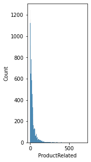

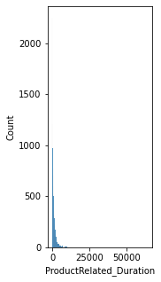

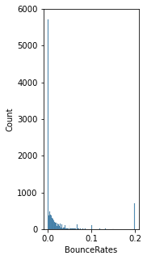

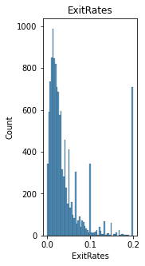

```python
features = [ 'Administrative', 'Administrative_Duration', 'Informational','Informational_Duration', 'ProductRelated', 'ProductRelated_Duration', 'BounceRates', 'ExitRates']
for i, feature in enumerate(features):
    plt.figure(figsize = (20, 5))
    plt.subplot(1, 8, i+1)
    sns.histplot(df[feature])
plt.title(feature)
plt.show()
```

Here, in this histogram, we can observe that there is a significant amount of abnormal distribution of the data.

In our dataset, we found a sizable number of outliers, especially in the features "Informational" and "Informational Duration." Therefore, We employed the Capping method, which entails defining a limit for the values regarded as outliers, to address these outliers. Then, any values outside or inside of this range are regarded as outliers. With this approach, the majority of the data can be kept while the outlier problem is still successfully resolved. But we were unable to use this strategy for the two features indicated above because doing so would leave the data with just one value.

```python
def cap_outliers(df, col, threshold=1.5):
    q1, q3 = df[col].quantile([0.25, 0.75])
    iqr = q3 - q1
    upper_bound = q3 + threshold * iqr
    lower_bound = q1 - threshold * iqr
    df[col] = df[col].apply(lambda x: upper_bound if x > upper_bound else x)
    df[col] = df[col].apply(lambda x: lower_bound if x < lower_bound else x)
    return df

outliers = ['Administrative', 'Administrative_Duration', 'ProductRelated', 'ProductRelated_Duration', 'BounceRates', 'ExitRates']
for col in outliers:
    df = cap_outliers(df, col)
```

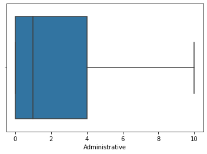

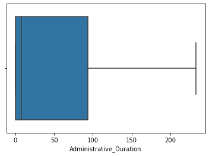

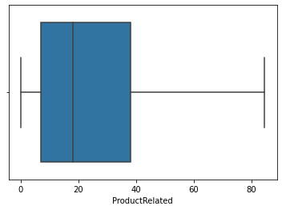

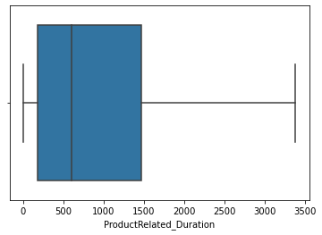

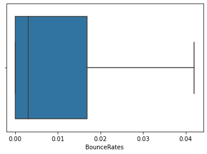

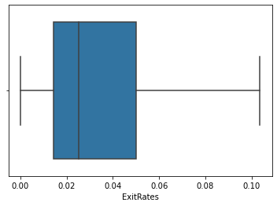

```python
outliers = ['Administrative', 'Administrative_Duration', 'ProductRelated', 'ProductRelated_Duration', 'BounceRates', 'ExitRates']
for col in outliers:
    plt.figure()
    sns.boxplot(x=col, data=df)
```

The problem of outliers has been resolved using the Capping method.

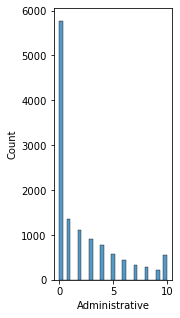

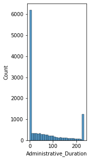

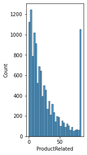

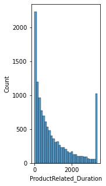

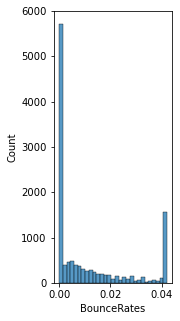

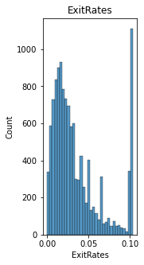

```python
features = [ 'Administrative', 'Administrative_Duration', 'ProductRelated', 'ProductRelated_Duration', 'BounceRates', 'ExitRates']
for i, feature in enumerate(features):
    plt.figure(figsize = (20, 5))
    plt.subplot(1, 8, i+1)
    sns.histplot(df[feature])
plt.title(feature)
plt.show()
```

### Implementing Min Max Scalar to normalize the values of the features

- Min Max Scalar changes the data by adjusting the features to a designated interval. The values are modified to a defined interval, maintaining the shape of the original distribution.

```python
features = ['Administrative', 'Administrative_Duration', 'ProductRelated', 'ProductRelated_Duration', 'BounceRates', 'ExitRates']
scaler = MinMaxScaler()
scaler.fit(df[features])
df[features] = scaler.transform(df[features])
```

```python
df.head()
```

|  | Administrative | Administrative_Duration | Informational | Informational_Duration | ProductRelated | ProductRelated_Duration | BounceRates | ExitRates | Revenue |
| --- | --- | --- | --- | --- | --- | --- | --- | --- | --- |
| 0 | 0.0 | 0.0 | 0 | 0.0 | 0.011834 | 0.000000 | 1.000000 | 1.000000 | 0 |
| 1 | 0.0 | 0.0 | 0 | 0.0 | 0.023669 | 0.018911 | 0.000000 | 0.965517 | 0 |
| 2 | 0.0 | 0.0 | 0 | 0.0 | 0.011834 | 0.000000 | 1.000000 | 1.000000 | 0 |
| 3 | 0.0 | 0.0 | 0 | 0.0 | 0.023669 | 0.000788 | 1.000000 | 1.000000 | 0 |
| 4 | 0.0 | 0.0 | 0 | 0.0 | 0.118343 | 0.185421 | 0.475835 | 0.482759 | 0 |

```python
df.shape
```

```
(12330, 9)
```

```python
print(df['Revenue'].value_counts())
```

```
0    10422
1     1908
Name: Revenue, dtype: int64
```

The target variable in this case is "Revenue", and as seen from the values, it is highly imbalanced with only 1908 observations of positive revenue (1) and 10422 observations of negative revenue (0). This imbalanced distribution of the target variable can affect the performance of the machine learning models and hence need to be treated before modeling.

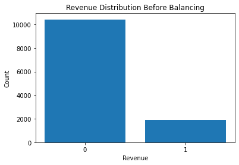

```python
revenue_count = df['Revenue'].value_counts()
plt.bar(revenue_count.index, revenue_count.values)
plt.xlabel('Revenue')
plt.ylabel('Count')
plt.xticks([0,1])
plt.title('Revenue Distribution Before Balancing')
plt.show()
```

The dataset in this case is imbalanced, as we can see. The dataset needs to be balanced in order for the algorithm to fit.

### Splitting the data into two sets: the independent variables (X) and the dependent variable (y)

```python
X = df.drop('Revenue', axis=1)
y = df['Revenue']
```

All of the columns in the dataframe "df"—aside from the target variable "Revenue"—are allocated to the X variable. Only "Revenue," the target value, is assigned to the y variable. In doing so, the feature set X and the target variable set Y are established.

### Balancing the Dataset Using Random Over Sampler

```python
ros = RandomOverSampler(random_state=0)
X, y = ros.fit_resample(X, y)
```

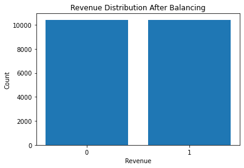

```python
revenue_count = pd.Series(y).value_counts()
plt.bar(revenue_count.index, revenue_count.values)
plt.xlabel('Revenue')
plt.ylabel('Count')
plt.xticks([0,1])
plt.title('Revenue Distribution After Balancing')
plt.show()
```

The dataset is now balanced as the Random Over sampler technique has been applied. This method replicated the minority class samples to match the number of samples in the majority class. The target variable, "Revenue," now has an equal distribution of 0 and 1.

```python
X.shape
```

```
(20844, 8)
```

```python
y.shape
```

```
(20844,)
```

### Spliting the Dataset into Train and Test data

```python
X_train, X_test, y_train, y_test = train_test_split(X, y, test_size=0.2, random_state=42)
```

The code splits the feature matrix, "X," and target variable, "y," into training and testing sets by using the train_test_split function from the sklearn.model_selection module. The function takes the inputs of X and y, and splits them into X_train, X_test, y_train, and y_test, with a test size of 20% and a random state of 42 to ensure reproducibility.

```python
X_train
```

|  | Administrative | Administrative_Duration | Informational | Informational_Duration | ProductRelated | ProductRelated_Duration | BounceRates | ExitRates |
| --- | --- | --- | --- | --- | --- | --- | --- | --- |
| 2487 | 0.0 | 0.000000 | 0 | 0.0 | 0.816568 | 0.193038 | 0.349879 | 0.515889 |
| 16790 | 0.2 | 0.248777 | 0 | 0.0 | 0.071006 | 0.072396 | 0.000000 | 0.275862 |
| 6346 | 0.0 | 0.000000 | 0 | 0.0 | 0.213018 | 0.142250 | 1.000000 | 0.884461 |
| 16598 | 0.0 | 0.000000 | 0 | 0.0 | 0.130178 | 0.088669 | 0.000000 | 0.193103 |
| 6105 | 0.5 | 0.656256 | 0 | 0.0 | 0.295858 | 0.317560 | 0.297397 | 0.181034 |
| ... | ... | ... | ... | ... | ... | ... | ... | ... |
| 11284 | 0.6 | 0.529570 | 0 | 0.0 | 0.402367 | 0.464061 | 0.025044 | 0.100720 |
| 11964 | 1.0 | 1.000000 | 0 | 0.0 | 0.295858 | 0.216402 | 0.000000 | 0.151351 |
| 5390 | 0.0 | 0.000000 | 0 | 0.0 | 0.035503 | 0.055848 | 0.000000 | 0.643678 |
| 860 | 0.0 | 0.000000 | 0 | 0.0 | 0.153846 | 0.090125 | 0.000000 | 0.160920 |
| 15795 | 0.0 | 0.000000 | 0 | 0.0 | 0.094675 | 0.098103 | 0.000000 | 0.275862 |

16675 rows × 8 columns

```python
y_train
```

```
2487     0
16790    1
6346     0
16598    1
6105     0
        ..
11284    1
11964    0
5390     0
860      0
15795    1
Name: Revenue, Length: 16675, dtype: int64
```

## Employing Various Machine Learning Algorithms

#### 1. K-Nearest Neighbors (KNN)

```python
knn = KNeighborsClassifier()
knn.fit(X_train, y_train)
y_pred_knn = knn.predict(X_test)
acc_knn = accuracy_score(y_test, y_pred_knn)
print("Accuracy of KNN: {:.2f}%".format(acc_knn*100))
```

```
Accuracy of KNN: 80.31%
```

The K-Nearest Neighbors algorithm has achieved an accuracy of 80.31%, meaning that it has correctly predicted the target variable in 80.31% of cases.

#### 2. Extreme Gradient Boosting (xgboost)

```python
xgb = xgb.XGBClassifier()
xgb.fit(X_train, y_train)
y_pred_xgb = xgb.predict(X_test)
acc_xgb = accuracy_score(y_test, y_pred_xgb)
print("Accuracy of xgb: {:.2f}%".format(acc_xgb*100))
```

```
Accuracy of xgb: 85.70%
```

The Extreme Gradient Boosting algorithm has achieved an accuracy of 85.70%, meaning that it has correctly predicted the target variable in 85.70% of cases.

#### 3. Random Forest

- Accuracy of Training Data.

```python
clf = RandomForestClassifier()
clf.fit(X_train, y_train)
train_accuracy = clf.score(X_train, y_train)
print("Accuracy of Random Forest training data: {:.2f}%".format(train_accuracy*100))
```

```
Accuracy of Random Forest training data: 99.89%
```

- Accuracy of Testing Data.

```python
rf = RandomForestClassifier()
rf.fit(X_train, y_train)
y_pred_rf = rf.predict(X_test)
acc_rf = accuracy_score(y_test, y_pred_rf)
print("Accuracy of Random Forest testing data: {:.2f}%".format(acc_rf*100))
```

```
Accuracy of Random Forest testing data: 95.75%
```

The Random Forest algorithm has achieved an accuracy of 95.75%, meaning that it has correctly predicted the target variable in 95.75% of cases.

We examined the issue of overfitting by comparing the accuracy scores between the training and testing data. In this instance, the difference between the two accuracy scores—99.89% on the training data and 95.75% on the testing data—is quite tiny. This shows that the model can generalise to new data and is not overfitting the training set. However, it's crucial to remember that a high accuracy score is not always a sign of a strong model; instead, performance metrics like precision, recall, F1 score, and confusion matrix should also be taken into account.Therefore, in the later stage, I have examined these performance metrics.

## Performance Evaluation

### Comparison of the Algorithms accuracy

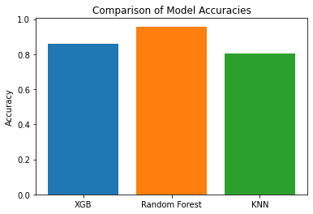

```python
models = [('XGB', xgb), ('Random Forest', rf), ('KNN', knn)]
accuracies = [acc_xgb, acc_rf, acc_knn]
fig, ax = plt.subplots()
x = np.arange(len(models))

for i, acc in enumerate(accuracies):
    ax.bar(x[i], acc)
ax.set_ylabel('Accuracy')
ax.set_xticks(x)
ax.set_xticklabels(['XGB', 'Random Forest', 'KNN'])
ax.set_title('Comparison of Model Accuracies')
plt.show()
```

Among the three models, the Random Forest model performs the best with an accuracy of 95.75%. The KNN model has an accuracy of 80.31% and the XGB model has an accuracy of 85.70%.

### Classification Report

#### 1. Classification Report for K-Nearest Neighbors

```python
report_knn = classification_report(y_test, y_pred_knn)
print("Classification Report for KNN: \n", report_knn)
```

```
Classification Report for KNN:
               precision    recall  f1-score   support

           0       0.91      0.67      0.77      2062
           1       0.74      0.93      0.83      2107

    accuracy                           0.80      4169
   macro avg       0.82      0.80      0.80      4169
weighted avg       0.82      0.80      0.80      4169
```

In this report, the precision for class 0 (no revenue) is 0.91, which means that 91% of the time the model correctly predicts when there is no revenue. The precision for class 1 (revenue) is 0.74, which means that 74% of the time the model correctly predicts when there is revenue. The recall for class 0 is 0.67, which means that the model correctly identifies 67% of the actual no revenue cases. The recall for class 1 is 0.93, which means that the model correctly identifies 93% of the actual revenue cases.F1-score is a balance between precision and recall, taking into account both true positive predictions and false positive predictions. The f1-score for class 0 (No revenue) is 0.77 and the f1-score for class 1 (Revenue) is 0.83.

The overall accuracy of the model is 80%. This means that 80% of the time the model correctly predicts whether there is revenue or not.

#### 2. Classification Report for Extreme Gradient Boosting

```python
report_xgb = classification_report(y_test, y_pred_xgb)
print("Classification Report for xgb: \n",report_xgb)
```

```
Classification Report for xgb:
               precision    recall  f1-score   support

           0       0.92      0.78      0.84      2062
           1       0.81      0.93      0.87      2107

    accuracy                           0.86      4169
   macro avg       0.87      0.86      0.86      4169
weighted avg       0.87      0.86      0.86      4169
```

The precision for class 0 (where revenue is 0) in this report is 0.92, which indicates that 92% of the time the model correctly predicted the observation to have a revenue of 0**. Similar to class 1, class 1 has a precision of 0.81, which means that 81% of the time, the model correctly predicted that the observation will have a revenue of 1. Recall for class 0 is 0.78, indicating that 78% of the observations with revenue of 0 were correctly classified by the model. Recall for class 1 is 0.93, indicating that 93% of the observations with revenue of 1 were correctly classified by the model.Class 0's F1-Score is 0.84, whereas class 1's is 0.87. The XGB model's overall accuracy is 0.86, which indicates that 86% of the time it successfully predicted the target variable.

#### 1. Classification Report For Random Forest

```python
report_rf = classification_report(y_test, y_pred_rf)
print("Classification Report for Random Forest: \n", report_rf)
```

```
Classification Report for Random Forest:
               precision    recall  f1-score   support

           0       0.99      0.92      0.96      2062
           1       0.93      0.99      0.96      2107

    accuracy                           0.96      4169
   macro avg       0.96      0.96      0.96      4169
weighted avg       0.96      0.96      0.96      4169
```

The classification report for Random Forest provides a comprehensive evaluation of the performance of the model. The precision of the model is calculated as the ratio of true positive predictions to the total number of positive predictions. In this case, the precision for class 0 is 0.99 and for class 1 it is 0.93. This means that when the model predicted a value as class 0, it was correct 99% of the time, and when it predicted a value as class 1, it was correct 93% of the time. The recall of the model is calculated as the ratio of true positive predictions to the total number of actual positive cases. In this case, the recall for class 0 is 0.92 and for class 1 it is 0.99. This means that the model correctly identified 92% of all actual class 0 cases and 99% of all actual class 1 cases. The f1-score is the harmonic mean of precision and recall and provides a balance between both. The f1-score for class 0 is 0.96 and for class 1 it is 0.96. This means that the overall balance between precision and recall is good for both classes.

The accuracy of the model is calculated as the ratio of correct predictions to the total number of predictions made by the model. In this case, the overall accuracy is 0.96, meaning that the model correctly predicted 96% of all the cases.

### Confusion Matrix

#### 1. Confusion Matrix for KNN

```
Confusion Matrix for KNN:
[[1385  677]
 [ 144 1963]]
```

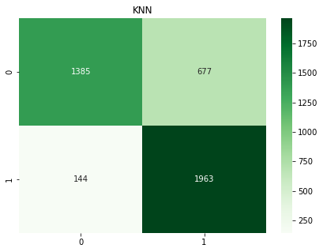

```python
cm_knn = confusion_matrix(y_test, y_pred_knn)
print("Confusion Matrix for KNN:")
print(cm_knn)

fig, ax = plt.subplots(figsize=(7,5))
sns.heatmap(cm_knn, annot=True, cmap="Greens", fmt='g', ax=ax)
ax.set_title("KNN")
plt.show()
```

The number of true positive, false positive, true negative, and false negative predictions made by the model are displayed in a 2x2 table known as the confusion matrix for KNN. There are 4 components in the table: The number of times the model accurately predicted the positive class is known as the true positive rate (TP). In this instance, the model accurately identified the positive class as 1963 occurrences. The number of times the model mispredicted the positive class is known as the false positive rate (FP). In this instance, the model predicted 677 occurrences as belonging to the positive class wrongly. The amount of times the model accurately predicted the negative class is known as True Negative (TN). 1385 of the instances in this instance fell into the negative class, as predicted by the model. False Negative (FN), this indicates how frequently the model predicted the negative class erroneously. In this instance, the model predicted 144 occurrences as belonging to the negative class wrongly.

#### 2. Confusion Matrix for XGB

```
Confusion Matrix for XGB:
[[1605  457]
 [ 139 1968]]
```

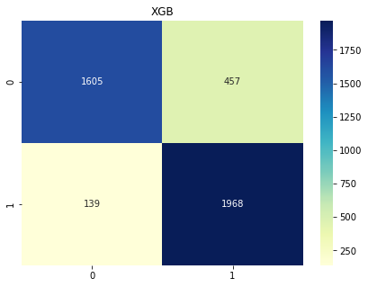

```python
cm_xgb = confusion_matrix(y_test, y_pred_xgb)
print("Confusion Matrix for XGB:")
print(cm_xgb)

fig, ax = plt.subplots(figsize=(7,5))
sns.heatmap(cm_xgb, annot=True, cmap="YlGnBu", fmt='g', ax=ax)
ax.set_title("XGB")
plt.show()
```

The confusion matrix for XGB displays the accuracy of the model in terms of correctly predicted positive cases (TP), correctly predicted negative cases (TN), falsely predicted positive cases (FP), and falsely predicted negative cases (FN). The number of times the positive class (1) was predicted by the model and was actually present is known as True Positives (TP). In this instance, 1968 positive cases were accurately predicted by the model. False Positives (FP) are the number of times the model predicted the positive class (1) when it was really negative. 457 erroneous positive predictions were made by the model in this instance. The percentage of times the model correctly predicted the negative class (0) and it actually was negative is known as True Negatives (TN). In this instance, 1605 of the negative situations that the model predicted were accurate. False Negatives (FN) are the instances in which a class was predicted by the model to be negative (class (0)) but was really positive. 139 false negative predictions were made by the model in this situation.

#### 3. Confusion Matrix for Random Forest

```
Confusion Matrix for Random Forest:
[[1901  161]
 [  16 2091]]
```

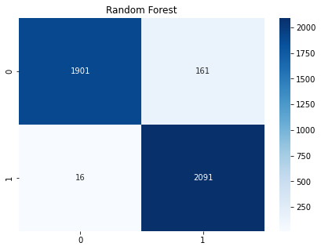

```python
cm_rf = confusion_matrix(y_test, y_pred_rf)
print("Confusion Matrix for Random Forest:")
print(cm_rf)

fig, ax = plt.subplots(figsize=(7,5))
cm_rf = confusion_matrix(y_test, y_pred_rf)
sns.heatmap(cm_rf, annot=True, cmap="Blues", fmt='g', ax=ax)
ax.set_title("Random Forest")
plt.show()
```

The performance of the model in terms of true positive (TP), true negative (TN), false positive (FP), and false negative (FN) predictions is displayed in the confusion matrix for Random Forest. The number of times the model accurately predicted the positive class is indicated by the TP count. 2091 instances of the positive class were accurately predicted by the model in this situation. The model's success rate in properly predicting the negative class is indicated by the TN count. 1901 instances of the negative class were accurately predicted by the model in this situation. The number of times the model predicted the positive class when the actual class was negative is shown by the FP count. In this situation, the model predicted 161 instances of the positive class inaccurately. The negative class was incorrectly predicted by the model a number of times, as indicated by the FN count, even though the actual class was positive. 16 instances of the negative class were predicted by the model in this scenario inaccurately.

#### AUC-ROC Curve

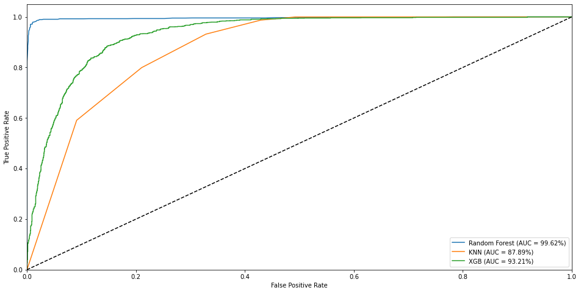

```python
plt.figure(figsize=(16, 8))

y_score_rf = rf.predict_proba(X_test)[:,1]
fpr_rf, tpr_rf, _ = roc_curve(y_test, y_score_rf)
auc_rf = roc_auc_score(y_test, y_score_rf)
plt.plot(fpr_rf, tpr_rf, label='Random Forest (AUC = {:.2f}%)'.format(auc_rf*100))

y_score_knn = knn.predict_proba(X_test)[:,1]
fpr_knn, tpr_knn, _ = roc_curve(y_test, y_score_knn)
auc_knn = roc_auc_score(y_test, y_score_knn)
plt.plot(fpr_knn, tpr_knn, label='KNN (AUC = {:.2f}%)'.format(auc_knn*100))

y_score_xgb = xgb.predict_proba(X_test)[:,1]
fpr_xgb, tpr_xgb, _ = roc_curve(y_test, y_score_xgb)
auc_xgb = roc_auc_score(y_test, y_score_xgb)
plt.plot(fpr_xgb, tpr_xgb, label='XGB (AUC = {:.2f}%)'.format(auc_xgb*100))

plt.plot([0,1],[0,1],'k--')
plt.xlim([0.0,1.0])
plt.ylim([0.0,1.05])
plt.xlabel('False Positive Rate')
plt.ylabel('True Positive Rate')
plt.legend(loc="lower right")
plt.show()
```

## Web User Interface

```python
import gradio as gr

rf = RandomForestClassifier()
rf.fit(X_train, y_train)

def predict(Administrative, Administrative_Duration, Informational, Informational_Duration, ProductRelated, ProductRelated_Duration, BounceRates, ExitRates):
    input_values = [Administrative, Administrative_Duration, Informational, Informational_Duration, ProductRelated, ProductRelated_Duration, BounceRates, ExitRates]
    prediction = rf.predict([input_values])[0]
    return "Predicted Output: " + str(prediction) + "\n\nNote: 0 means negative intention of purchase and 1 means positive intention of purchase."

inputs = [gr.inputs.Textbox(label="Administrative"),
gr.inputs.Textbox(label="Administrative_Duration"),
gr.inputs.Textbox(label="Informational"),
gr.inputs.Textbox(label="Informational_Duration"),
gr.inputs.Textbox(label="ProductRelated"),
gr.inputs.Textbox(label="ProductRelated_Duration"),
gr.inputs.Textbox(label="BounceRates"),
gr.inputs.Textbox(label="ExitRates"),]


interface = gr.Interface(predict, inputs, gr.outputs.Textbox(label="Predicted Output"), title="🛍️ Online Shoppers' Purchase Intention Predictor 🛍️")

interface.launch()
```

```
Running on local URL:  http://127.0.0.1:7860

To create a public link, set `share=True` in `launch()`.
```

[interactive chart not shown]